# logistic regression

## Packages

```r
library(tidyverse)
library(broom) # for later
```

## Basic logistic regression

Read in the rat data:

```r
my_url="http://www.utsc.utoronto.ca/~butler/d29/rat.txt"
rats=read_delim(my_url," ")
rats
```

| dose | status |
| --- | --- |
| 0 | lived |
| 1 | died |
| 2 | lived |
| 3 | lived |
| 4 | died |
| 5 | died |

These are 6 rats getting different doses of some poison, and what happened to them. For a rat getting larger dose, are they more likely to die?

Response variable categorical, but needs to be `factor`, so make one (can overwrite):

```r
class(rats$status)
```

```
[1] "character"
```

```r
rats = rats %>% mutate(status=factor(status))
class(rats$status)
```

```
[1] "factor"
```

```r
rats
```

| dose | status |
| --- | --- |
| 0 | lived |
| 1 | died |
| 2 | lived |
| 3 | lived |
| 4 | died |
| 5 | died |

now fit model:

```r
rats.1=glm(status~dose,family="binomial",data=rats)
summary(rats.1)
```

```
Call:
glm(formula = status ~ dose, family = "binomial", data = rats)

Deviance Residuals:
      1        2        3        4        5        6
 0.5835  -1.6254   1.0381   1.3234  -0.7880  -0.5835

Coefficients:
            Estimate Std. Error z value Pr(>|z|)
(Intercept)   1.6841     1.7979   0.937    0.349
dose         -0.6736     0.6140  -1.097    0.273

(Dispersion parameter for binomial family taken to be 1)

    Null deviance: 8.3178  on 5  degrees of freedom
Residual deviance: 6.7728  on 4  degrees of freedom
AIC: 10.773

Number of Fisher Scoring iterations: 4
```

what did we actually predict?

```r
rats$status
```

```
[1] lived died  lived lived died  died
Levels: died lived
```

First level is baseline (died), second is predicted (lived).

So negative slope means probability of **living** *decreases* as dose increases.

### predictions

Use `predict`. With just a model to predict from, uses original data `dose` values:

```r
p=predict(rats.1,se=T,type="response")
cbind(rats,p)
```

|  | dose | status | fit | se.fit | residual.scale |
| --- | --- | --- | --- | --- | --- |
| 1 | 0 | lived | 0.8434490 | 0.2373945 | 1 |
| 2 | 1 | died | 0.7331122 | 0.2569246 | 1 |
| 3 | 2 | lived | 0.5834187 | 0.2394051 | 1 |
| 4 | 3 | lived | 0.4165813 | 0.2394051 | 1 |
| 5 | 4 | died | 0.2668878 | 0.2569246 | 1 |
| 6 | 5 | died | 0.1565510 | 0.2373945 | 1 |

To predict for other doses, create a new data frame of them first:

```r
doses=c(2.5,3.5,6)
new=tibble(dose=doses)
new
```

| dose |
| --- |
| 2.5 |
| 3.5 |
| 6.0 |

```r
p=predict(rats.1,new,type="response")
cbind(new,p)
```

|  | dose | p |
| --- | --- | --- |
| 1 | 2.5 | 0.50000000 |
| 2 | 3.5 | 0.33768072 |
| 3 | 6.0 | 0.08645061 |

## Rats part 2

More data (60 rats), arranged differently:

```r
my_url="http://www.utsc.utoronto.ca/~butler/d29/rat2.txt"
rat2=read_delim(my_url," ")
```

[output not shown]

```r
rat2
```

| dose | lived | died |
| --- | --- | --- |
| 0 | 10 | 0 |
| 1 | 7 | 3 |
| 2 | 6 | 4 |
| 3 | 4 | 6 |
| 4 | 2 | 8 |
| 5 | 1 | 9 |

Have *frequencies*: number of rats living or dying at each dose. Each line of data represents many rats (10), not just one.

Now have to *create* response variable (don’t just have a “lived” or “died” in a column).

Create two-column response, column of lived, column of died:

```r
response=with(rat2,cbind(lived,died))
response
```

```
     lived died
[1,]    10    0
[2,]     7    3
[3,]     6    4
[4,]     4    6
[5,]     2    8
[6,]     1    9
```

```r
class(response)
```

```
[1] "matrix"
```

then use that on the left of the squiggle. Modelling probability of *first* column:

```r
rat2.1=glm(response~dose,family="binomial",
  data=rat2)
summary(rat2.1)
```

```
Call:
glm(formula = response ~ dose, family = "binomial", data = rat2)

Deviance Residuals:
      1        2        3        4        5        6
 1.3421  -0.7916  -0.1034   0.1034   0.0389   0.1529

Coefficients:
            Estimate Std. Error z value Pr(>|z|)
(Intercept)   2.3619     0.6719   3.515 0.000439 ***
dose         -0.9448     0.2351  -4.018 5.87e-05 ***
---
Signif. codes:  0 ‘***’ 0.001 ‘**’ 0.01 ‘*’ 0.05 ‘.’ 0.1 ‘ ’ 1

(Dispersion parameter for binomial family taken to be 1)

    Null deviance: 27.530  on 5  degrees of freedom
Residual deviance:  2.474  on 4  degrees of freedom
AIC: 18.94

Number of Fisher Scoring iterations: 4
```

Probability of living decreases with increasing dose, and is now significant.

Using a data frame as response doesn’t work:

```r
response = rat2 %>% select(lived,died)
rat2.1a=glm(response~dose,family="binomial",data=rat2)
```

```
Error in model.frame.default(formula = response ~ dose, data = rat2, drop.unused.levels = TRUE) :
  invalid type (list) for variable 'response'
```

but this does:

```r
response = rat2 %>% select(lived,died) %>% as.matrix()
rat2.1b=glm(response~dose,family="binomial",data=rat2)
summary(rat2.1b)
```

```
Call:
glm(formula = response ~ dose, family = "binomial", data = rat2)

Deviance Residuals:
      1        2        3        4        5        6
 1.3421  -0.7916  -0.1034   0.1034   0.0389   0.1529

Coefficients:
            Estimate Std. Error z value Pr(>|z|)
(Intercept)   2.3619     0.6719   3.515 0.000439 ***
dose         -0.9448     0.2351  -4.018 5.87e-05 ***
---
Signif. codes:  0 ‘***’ 0.001 ‘**’ 0.01 ‘*’ 0.05 ‘.’ 0.1 ‘ ’ 1

(Dispersion parameter for binomial family taken to be 1)

    Null deviance: 27.530  on 5  degrees of freedom
Residual deviance:  2.474  on 4  degrees of freedom
AIC: 18.94

Number of Fisher Scoring iterations: 4
```

Predictions (using original doses in data set):

```r
p=predict(rat2.1,type="response")
cbind(rat2,p)
```

|  | dose | lived | died | p |
| --- | --- | --- | --- | --- |
| 1 | 0 | 10 | 0 | 0.9138762 |
| 2 | 1 | 7 | 3 | 0.8048905 |
| 3 | 2 | 6 | 4 | 0.6159474 |
| 4 | 3 | 4 | 6 | 0.3840526 |
| 5 | 4 | 2 | 8 | 0.1951095 |
| 6 | 5 | 1 | 9 | 0.0861238 |

## Plotting observed proportions against predictions

With multiple observations per line, can plot predicted probabilities of a rat living at that dose against the actual proportion of rats that lived.

- Add predictions to data frame
- Calculate observed proportion
- Plot observed proportions against dose as points
- Plot predictions joined by lines
- label the y-axis properly:

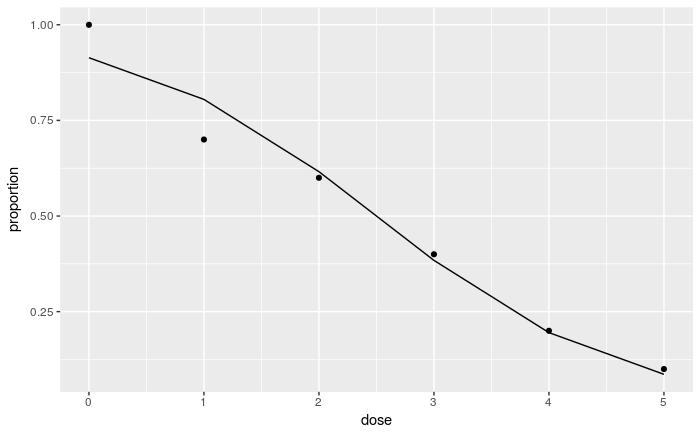

```r
rat2 %>% bind_cols(pred=p) %>%
  mutate(obs=lived/(lived+died)) %>%
  ggplot(aes(x=dose,y=obs))+geom_point()+
    geom_line(aes(y=pred))+
    scale_y_continuous("proportion")
```

## Sepsis data

```r
my_url="http://www.utsc.utoronto.ca/~butler/d29/sepsis.txt"
sepsis=read_delim(my_url," ")
```

[output not shown]

```r
sepsis
```

| death | shock | malnut | alcohol | age | bowelinf |
| --- | --- | --- | --- | --- | --- |
| 0 | 0 | 0 | 0 | 56 | 0 |
| 0 | 0 | 0 | 0 | 80 | 0 |
| 0 | 0 | 0 | 0 | 61 | 0 |
| 0 | 0 | 0 | 0 | 26 | 0 |
| 0 | 0 | 0 | 0 | 53 | 0 |
| 1 | 0 | 1 | 0 | 87 | 0 |
| 0 | 0 | 0 | 0 | 21 | 0 |
| 1 | 0 | 0 | 1 | 69 | 0 |
| 0 | 0 | 0 | 0 | 57 | 0 |
| 0 | 0 | 1 | 0 | 76 | 0 |

[output cut: 96 more lines]

Predict probability of death (`death=1`) from everything else

```r
sepsis.1=glm(death~., family="binomial", data=sepsis)
summary(sepsis.1)
```

```
Call:
glm(formula = death ~ ., family = "binomial", data = sepsis)

Deviance Residuals:
    Min       1Q   Median       3Q      Max
-1.3277  -0.4204  -0.0781  -0.0274   3.2946

Coefficients:
            Estimate Std. Error z value Pr(>|z|)
(Intercept) -9.75391    2.54170  -3.838 0.000124 ***
shock        3.67387    1.16481   3.154 0.001610 **
malnut       1.21658    0.72822   1.671 0.094798 .
alcohol      3.35488    0.98210   3.416 0.000635 ***
age          0.09215    0.03032   3.039 0.002374 **
bowelinf     2.79759    1.16397   2.403 0.016240 *
---
Signif. codes:  0 ‘***’ 0.001 ‘**’ 0.01 ‘*’ 0.05 ‘.’ 0.1 ‘ ’ 1

(Dispersion parameter for binomial family taken to be 1)

    Null deviance: 105.528  on 105  degrees of freedom
Residual deviance:  53.122  on 100  degrees of freedom
AIC: 65.122

Number of Fisher Scoring iterations: 7
```

Take out `malnut`:

```r
sepsis.2=update(sepsis.1,.~.-malnut)
summary(sepsis.2)
```

```
Call:
glm(formula = death ~ shock + alcohol + age + bowelinf, family = "binomial",
    data = sepsis)

Deviance Residuals:
     Min        1Q    Median        3Q       Max
-1.26192  -0.50391  -0.10690  -0.04112   3.06000

Coefficients:
            Estimate Std. Error z value Pr(>|z|)
(Intercept) -8.89459    2.31689  -3.839 0.000124 ***
shock        3.70119    1.10353   3.354 0.000797 ***
alcohol      3.18590    0.91725   3.473 0.000514 ***
age          0.08983    0.02922   3.075 0.002106 **
bowelinf     2.38647    1.07227   2.226 0.026039 *
---
Signif. codes:  0 ‘***’ 0.001 ‘**’ 0.01 ‘*’ 0.05 ‘.’ 0.1 ‘ ’ 1

(Dispersion parameter for binomial family taken to be 1)

    Null deviance: 105.528  on 105  degrees of freedom
Residual deviance:  56.073  on 101  degrees of freedom
AIC: 66.073

Number of Fisher Scoring iterations: 7
```

All coefficients positive (why?)

Do some predictions, for individuals 4, 1, 2, 11, 32:

```r
my_rows=c(4,1,2,11,32)
new = sepsis %>% slice(my_rows)
p=predict(sepsis.2,new,type="response")
cbind(new,p)
```

|  | death | shock | malnut | alcohol | age | bowelinf | p |
| --- | --- | --- | --- | --- | --- | --- | --- |
| 1 | 0 | 0 | 0 | 0 | 26 | 0 | 0.001415347 |
| 2 | 0 | 0 | 0 | 0 | 56 | 0 | 0.020552383 |
| 3 | 0 | 0 | 0 | 0 | 80 | 0 | 0.153416834 |
| 4 | 1 | 0 | 0 | 1 | 66 | 1 | 0.931290137 |
| 5 | 1 | 0 | 0 | 1 | 49 | 0 | 0.213000997 |

Note effect of age (first three rows) and of risk factors (last two) on prob of death.

Diagnostic: plot residuals against anything as usual:

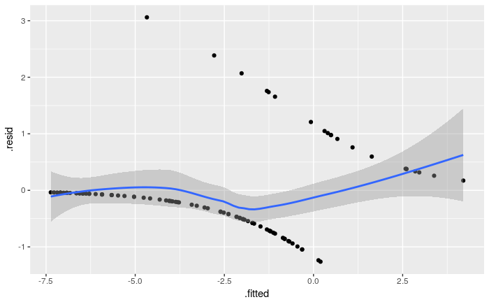

```r
ggplot(sepsis.2,aes(x=.fitted,y=.resid))+geom_point()+geom_smooth()
```

Hard to read: positive residuals are from people who died, negative ones from people who survived. As long as smooth trend more or less straight across, OK.

Also need lack of trend of residuals vs. age. These are in different data frames, so either get them from right place:

```r
ggplot(sepsis.2,aes(x=sepsis$age,y=.resid))+geom_point()
```

[output not shown]

or use `augment` from `broom` (look at all the columns):

```r
library(broom)
d=augment(sepsis.2)
d
```

| death | shock | alcohol | age | bowelinf | .fitted | .se.fit | .resid | .hat | .sigma | .cooksd | .std.resid |
| --- | --- | --- | --- | --- | --- | --- | --- | --- | --- | --- | --- |
| 0 | 0 | 0 | 56 | 0 | -3.86401185 | 0.8306454 | -0.20379658 | 0.013889145 | 0.7485367 | 5.994252e-05 | -0.20522677 |
| 0 | 0 | 0 | 80 | 0 | -1.70804982 | 0.5691084 | -0.57714268 | 0.042066147 | 0.7464926 | 1.661480e-03 | -0.58967868 |
| 0 | 0 | 0 | 61 | 0 | -3.41485309 | 0.7298068 | -0.25437065 | 0.016415867 | 0.7483786 | 1.115884e-04 | -0.25648457 |
| 0 | 0 | 0 | 26 | 0 | -6.55896439 | 1.5906929 | -0.05322310 | 0.003576201 | 0.7487990 | 1.021038e-06 | -0.05331853 |
| 0 | 0 | 0 | 53 | 0 | -4.13350710 | 0.8971448 | -0.17832276 | 0.012495583 | 0.7486030 | 4.107231e-05 | -0.17944744 |
| 1 | 0 | 0 | 87 | 0 | -1.07922756 | 0.6342913 | 1.65637626 | 0.076165337 | 0.7287185 | 5.251718e-02 | 1.72330390 |
| 0 | 0 | 0 | 21 | 0 | -7.00812314 | 1.7281186 | -0.04252284 | 0.002696338 | 0.7488059 | 4.904111e-07 | -0.04258028 |
| 1 | 0 | 1 | 69 | 0 | 0.48970489 | 0.6041400 | 0.97772826 | 0.085987267 | 0.7418016 | 1.261489e-02 | 1.02268537 |
| 0 | 0 | 0 | 57 | 0 | -3.77418010 | 0.8093744 | -0.21305578 | 0.014370777 | 0.7485105 | 6.791684e-05 | -0.21460337 |
| 0 | 0 | 0 | 76 | 0 | -2.06737683 | 0.5626867 | -0.48812042 | 0.031565124 | 0.7471735 | 8.516209e-04 | -0.49601152 |

[output cut: 96 more lines]

and then plot (now in *same* data frame):

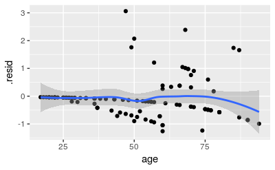

```r
ggplot(d,aes(x=age,y=.resid))+geom_point()+geom_smooth()
```

The long string of points is people with no risk factors who survived (`death=0`). Prob of survival decreases with age, so these residuals get gradually more negative.

Apparently no trend on this plot, so relationship with age appears appropriate.

The other explanatory variables are 0-1, so assess their relationship with residuals by boxplots, eg. `alcohol`:

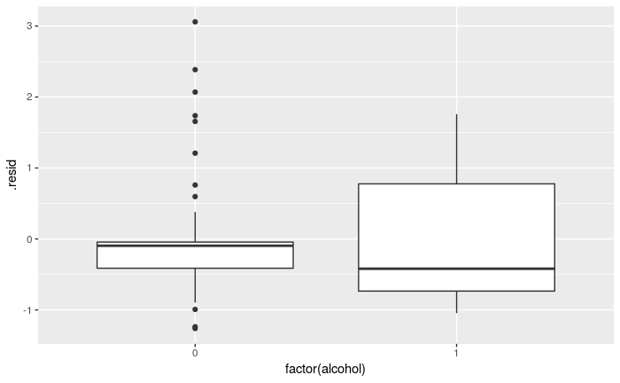

```r
ggplot(d,aes(x=factor(alcohol),y=.resid))+geom_boxplot()
```

Centre of each group should be zero; median for alcoholics is a bit low.

## Something else

Let’s create a much simpler model containing just age and alcoholism and do some predictions for it:

```r
sepsis.3=update(sepsis.2,.~.-shock-bowelinf)
summary(sepsis.3)
```

```
Call:
glm(formula = death ~ alcohol + age, family = "binomial", data = sepsis)

Deviance Residuals:
    Min       1Q   Median       3Q      Max
-1.2690  -0.6979  -0.2544  -0.1562   2.3624

Coefficients:
            Estimate Std. Error z value Pr(>|z|)
(Intercept) -5.66676    1.34036  -4.228 2.36e-05 ***
alcohol      1.90292    0.60939   3.123 0.001792 **
age          0.06255    0.01879   3.328 0.000874 ***
---
Signif. codes:  0 ‘***’ 0.001 ‘**’ 0.01 ‘*’ 0.05 ‘.’ 0.1 ‘ ’ 1

(Dispersion parameter for binomial family taken to be 1)

    Null deviance: 105.528  on 105  degrees of freedom
Residual deviance:  79.925  on 103  degrees of freedom
AIC: 85.925

Number of Fisher Scoring iterations: 6
```

Let’s do some predictions for all combinations of `age` 25, 50, 75 and `alcohol` 0 and 1. Here’s my procedure for doing that:

```r
ages=c(25,50,75)
alcohols=c(0,1)
new=crossing(age=ages,alcohol=alcohols)
new
```

| age | alcohol |
| --- | --- |
| 25 | 0 |
| 25 | 1 |
| 50 | 0 |
| 50 | 1 |
| 75 | 0 |
| 75 | 1 |

The column names in `new` must be *exactly* the same as in the original data frame.

Then, feed `new` into `predict` as usual:

```r
p=predict(sepsis.3,new,type="response")
cbind(new,p)
```

|  | age | alcohol | p |
| --- | --- | --- | --- |
| 1 | 25 | 0 | 0.01625365 |
| 2 | 25 | 1 | 0.09973866 |
| 3 | 50 | 0 | 0.07314573 |
| 4 | 50 | 1 | 0.34605535 |
| 5 | 75 | 0 | 0.27375880 |
| 6 | 75 | 1 | 0.71652391 |

Consistent with positive slopes in logistic regression.